# Machine Learning Project

Jeanette Lee, Kevin Stadelmann, Marc Weber, Patricia Wellhöfer

05 Januar 2022

# 1 Introduction

The objective of the analysis is to determine the “credit-worthiness” of applicants using socio-demographic information (gender, education, marital status, etc.) and credit history data to predict the probability of repayment and to categorize customers as “good” or “bad”.

Data Source: [link](https://www.kaggle.com/rikdifos/credit-card-approval-prediction) (last update: 24-03-2020)

# 2 Setup

```r
library(magrittr)
library(data.table)
library(dplyr)
library(lubridate)
library(caret)
library(knitr)
library(inspectdf)
library(ggplot2)
library(GGally)
library(gridExtra)
library(car)
library(nnet)
library(ROCR)

opts_chunk$set(fig.align="center", echo=TRUE)
knit_hooks$set(inline=function(x) { prettyNum(x, big.mark=",") })
```

# 3 Data Preparation

## 3.1 Data Import

```r
df.ar <- fread("data/application_record.csv", stringsAsFactors = TRUE)
df.cr <- fread("data/credit_record.csv", stringsAsFactors = TRUE)
```

## 3.2 View Data

### 3.2.1 Application Record Dataframe

This dataset includes the demographic data of applicants.  
- DAYS_BIRTH and DAYS_EMPLOYED columns count backwards from “current” day (0), yesterday (-1), etc.  
- DAYS_EMPLOYED is positive, if the person is currently unemployed

**Data Summary**

```
## Classes 'data.table' and 'data.frame':   438557 obs. of  18 variables:
##  $ ID                 : int  5008804 5008805 5008806 5008808 5008809 5008810 5008811 5008812 5008813 5008814 ...
##  $ CODE_GENDER        : Factor w/ 2 levels "F","M": 2 2 2 1 1 1 1 1 1 1 ...
##  $ FLAG_OWN_CAR       : Factor w/ 2 levels "N","Y": 2 2 2 1 1 1 1 1 1 1 ...
##  $ FLAG_OWN_REALTY    : Factor w/ 2 levels "N","Y": 2 2 2 2 2 2 2 2 2 2 ...
##  $ CNT_CHILDREN       : int  0 0 0 0 0 0 0 0 0 0 ...
##  $ AMT_INCOME_TOTAL   : num  427500 427500 112500 270000 270000 ...
##  $ NAME_INCOME_TYPE   : Factor w/ 5 levels "Commercial associate",..: 5 5 5 1 1 1 1 2 2 2 ...
##  $ NAME_EDUCATION_TYPE: Factor w/ 5 levels "Academic degree",..: 2 2 5 5 5 5 5 2 2 2 ...
##  $ NAME_FAMILY_STATUS : Factor w/ 5 levels "Civil marriage",..: 1 1 2 4 4 4 4 3 3 3 ...
##  $ NAME_HOUSING_TYPE  : Factor w/ 6 levels "Co-op apartment",..: 5 5 2 2 2 2 2 2 2 2 ...
##  $ DAYS_BIRTH         : int  -12005 -12005 -21474 -19110 -19110 -19110 -19110 -22464 -22464 -22464 ...
##  $ DAYS_EMPLOYED      : int  -4542 -4542 -1134 -3051 -3051 -3051 -3051 365243 365243 365243 ...
##  $ FLAG_MOBIL         : int  1 1 1 1 1 1 1 1 1 1 ...
##  $ FLAG_WORK_PHONE    : int  1 1 0 0 0 0 0 0 0 0 ...
##  $ FLAG_PHONE         : int  0 0 0 1 1 1 1 0 0 0 ...
##  $ FLAG_EMAIL         : int  0 0 0 1 1 1 1 0 0 0 ...
##  $ OCCUPATION_TYPE    : Factor w/ 19 levels "","Accountants",..: 1 1 18 16 16 16 16 1 1 1 ...
##  $ CNT_FAM_MEMBERS    : num  2 2 2 1 1 1 1 1 1 1 ...
##  - attr(*, ".internal.selfref")=<externalptr>
```

**Sample of Dataset**

| ID | CODE_GENDER | FLAG_OWN_CAR | FLAG_OWN_REALTY | CNT_CHILDREN | AMT_INCOME_TOTAL | NAME_INCOME_TYPE | NAME_EDUCATION_TYPE | NAME_FAMILY_STATUS | NAME_HOUSING_TYPE | DAYS_BIRTH | DAYS_EMPLOYED | FLAG_MOBIL | FLAG_WORK_PHONE | FLAG_PHONE | FLAG_EMAIL | OCCUPATION_TYPE | CNT_FAM_MEMBERS |
| --- | --- | --- | --- | --- | --- | --- | --- | --- | --- | --- | --- | --- | --- | --- | --- | --- | --- |
| 5008804 | M | Y | Y | 0 | 427500 | Working | Higher education | Civil marriage | Rented apartment | -12005 | -4542 | 1 | 1 | 0 | 0 |  | 2 |
| 5008805 | M | Y | Y | 0 | 427500 | Working | Higher education | Civil marriage | Rented apartment | -12005 | -4542 | 1 | 1 | 0 | 0 |  | 2 |
| 5008806 | M | Y | Y | 0 | 112500 | Working | Secondary / secondary special | Married | House / apartment | -21474 | -1134 | 1 | 0 | 0 | 0 | Security staff | 2 |
| 5008808 | F | N | Y | 0 | 270000 | Commercial associate | Secondary / secondary special | Single / not married | House / apartment | -19110 | -3051 | 1 | 0 | 1 | 1 | Sales staff | 1 |
| 5008809 | F | N | Y | 0 | 270000 | Commercial associate | Secondary / secondary special | Single / not married | House / apartment | -19110 | -3051 | 1 | 0 | 1 | 1 | Sales staff | 1 |
| 5008810 | F | N | Y | 0 | 270000 | Commercial associate | Secondary / secondary special | Single / not married | House / apartment | -19110 | -3051 | 1 | 0 | 1 | 1 | Sales staff | 1 |

### 3.2.2 Credit Record Dataframe

This dataset includes the historical data of user behaviour.  
- MONTHS_BALANCE column counts backward from “current” month (0), previous month (-1), 2 months prior (-2), etc.  
- STATUS column: 0 = 1-29 days past due, 1 = 30-59 days past due, 2 = 60-89 days overdue, 3 = 90-119 days overdue, 4 = 120-149 days overdue, 5 = overdue or bad debts, write-offs for more than 150 days, C = paid off that month, X = no loan for the month

**Data Summary**

```
## Classes 'data.table' and 'data.frame':   1048575 obs. of  3 variables:
##  $ ID            : int  5001711 5001711 5001711 5001711 5001712 5001712 5001712 5001712 5001712 5001712 ...
##  $ MONTHS_BALANCE: int  0 -1 -2 -3 0 -1 -2 -3 -4 -5 ...
##  $ STATUS        : Factor w/ 8 levels "0","1","2","3",..: 8 1 1 1 7 7 7 7 7 7 ...
##  - attr(*, ".internal.selfref")=<externalptr>
```

**Sample of Dataset**

| ID | MONTHS_BALANCE | STATUS |
| --- | --- | --- |
| 5001711 | 0 | X |
| 5001711 | -1 | 0 |
| 5001711 | -2 | 0 |
| 5001711 | -3 | 0 |
| 5001712 | 0 | C |
| 5001712 | -1 | C |

## 3.3 Cleaning and Joining Datasets

### 3.3.1 Cleaning application_record.csv

Removed duplicate IDs from application_record.csv

```r
duplicates <- df.ar %>% group_by(ID) %>% summarise(count = n()) %>% filter(count > 1)
df.ar.mod <- df.ar %>% filter(!ID %in% duplicates$ID)
```

### 3.3.2 Cleaning credit_record.csv

The original dataset was made available on 24-03-2020, so it is presumed “current” month is March 2020. From months_balance we create a new column indicating the month for each observation. Observations older than 2 years are removed.

```r
# Extract month and year from months_balance in df.cr
df.cr$month_balance <- format(as.Date("2020-03-24") %m+% months(df.cr$MONTHS_BALANCE), "%B")

# Remove records older than 2 years
df.cr.mod <- df.cr %>% filter(MONTHS_BALANCE > -24)

# Assign customer status
df.status <- df.cr.mod %>% group_by(ID) %>%
  summarise(cnt_status_good = length(STATUS[STATUS==0|STATUS==1|STATUS=='C']),
            cnt_status_bad = n() - cnt_status_good,
            percent_good = round(cnt_status_good / n() * 100)) %>%
  mutate(customer_status_good = ifelse(percent_good >= 50, 1, 0)) %>%
  select(ID, customer_status_good, percent_good, cnt_status_good, cnt_status_bad)

df.status$customer_status_good <- as.factor(df.status$customer_status_good)
```

### 3.3.3 Join datasets

The two cleaned datasets are joined and only records where IDs exist in both are kept.

```r
df.cc.raw <- inner_join(x = df.status, y = df.ar.mod, by = "ID") %>%
  mutate(ID = as.factor(ID),
         CNT_FAM_MEMBERS = as.integer(CNT_FAM_MEMBERS),
         age_years = as.numeric(round(DAYS_BIRTH * (-1) / 365.25), 0),       # days -> years
         work_years = as.numeric(round((DAYS_EMPLOYED * (-1) / 365.25), 0)), # days -> years
         FLAG_MOBIL = as.factor(FLAG_MOBIL),
         FLAG_WORK_PHONE = as.factor(FLAG_WORK_PHONE),
         FLAG_PHONE = as.factor(FLAG_PHONE),
         FLAG_EMAIL = as.factor(FLAG_EMAIL))

setnames(df.cc.raw, tolower(names(df.cc.raw)))   # change column names to lower case
```

```r
df.cc.raw %>% select(-id) %>% select_if(is.factor) %>% sapply(., FUN = table)
table(df.cc.raw$cnt_fam_members)
table(df.cc.raw$cnt_children)
```

```r
df.cc.raw <- df.cc.raw[df.cc.raw$cnt_fam_members < 7, ]

# combine 'Academic degree' with 'Higher education' and set order of levels in education type
df.cc.raw$name_education_type <- recode_factor(df.cc.raw$name_education_type, "Academic degree" = "Higher education")
df.cc.raw$name_education_type <- factor(df.cc.raw$name_education_type, levels=c("Lower secondary", "Secondary / secondary special", "Incomplete higher", "Higher education"), ordered = TRUE)

df.cc.raw$work_years[df.cc.raw$work_years == '-1000'] <- NA                  # -ve = pensioner
levels(df.cc.raw$occupation_type)[levels(df.cc.raw$occupation_type)==""] <- "NA"

# select columns (exclude months_balance, days_birth, days_employed and flag_mobil)
df.cc <- df.cc.raw %>%
  select(id,
         code_gender,
         age_years,
         name_education_type,
         name_income_type,
         name_housing_type,
         name_family_status,
         cnt_children,
         cnt_fam_members,
         flag_own_car,
         flag_own_realty,
         work_years,
         amt_income_total,
         occupation_type,
         flag_work_phone,
         flag_phone,
         flag_email,
         customer_status_good,
         percent_good,
         cnt_status_good,
         cnt_status_bad)
```

### 3.3.4 Remove duplicates and NA

Some IDs appear to be the same individual (with different IDs) as all other columns are the same. We only keep one observation, removing duplicates.

```r
df.cc <- df.cc[!duplicated(df.cc[c(2:17)]),]
df.cc <- na.omit(df.cc)                                                        # remove NA-values
```

### 3.3.5 Check Final Dataframe

**Data Summary**

```
## tibble [7,832 x 21] (S3: tbl_df/tbl/data.frame)
##  $ id                  : Factor w/ 32848 levels "5008804","5008805",..: 1 3 4 11 12 18 21 24 25 27 ...
##  $ code_gender         : Factor w/ 2 levels "F","M": 2 2 1 2 2 1 1 1 2 2 ...
##  $ age_years           : num [1:7832] 33 59 52 46 49 29 27 30 35 32 ...
##  $ name_education_type : Ord.factor w/ 4 levels "Lower secondary"<..: 4 2 2 4 2 3 2 2 2 4 ...
##  $ name_income_type    : Factor w/ 5 levels "Commercial associate",..: 5 5 1 5 1 5 5 5 5 1 ...
##  $ name_housing_type   : Factor w/ 6 levels "Co-op apartment",..: 5 2 2 2 2 2 2 2 2 2 ...
##  $ name_family_status  : Factor w/ 5 levels "Civil marriage",..: 1 2 4 2 2 2 2 4 2 2 ...
##  $ cnt_children        : int [1:7832] 0 0 0 0 0 0 0 1 3 1 ...
##  $ cnt_fam_members     : int [1:7832] 2 2 1 2 2 2 2 2 5 3 ...
##  $ flag_own_car        : Factor w/ 2 levels "N","Y": 2 2 1 2 2 2 1 1 2 1 ...
##  $ flag_own_realty     : Factor w/ 2 levels "N","Y": 2 2 2 2 2 1 2 2 2 2 ...
##  $ work_years          : num [1:7832] 12 3 8 2 3 3 4 4 3 6 ...
##  $ amt_income_total    : num [1:7832] 427500 112500 270000 270000 135000 ...
##  $ occupation_type     : Factor w/ 19 levels "NA","Accountants",..: 1 18 16 2 10 2 10 1 10 12 ...
##  $ flag_work_phone     : Factor w/ 2 levels "0","1": 2 1 1 2 1 1 1 1 1 1 ...
##  $ flag_phone          : Factor w/ 2 levels "0","1": 1 1 2 2 1 1 2 1 1 1 ...
##  $ flag_email          : Factor w/ 2 levels "0","1": 1 1 2 2 1 1 1 1 1 1 ...
##  $ customer_status_good: Factor w/ 2 levels "0","1": 2 2 1 2 1 2 2 2 2 2 ...
##  $ percent_good        : num [1:7832] 94 50 40 100 0 100 100 100 100 93 ...
##  $ cnt_status_good     : int [1:7832] 15 12 2 6 0 24 24 24 16 14 ...
##  $ cnt_status_bad      : int [1:7832] 1 12 3 0 8 0 0 0 0 1 ...
##  - attr(*, "na.action")= 'omit' Named int [1:1502] 4 8 18 26 36 42 58 60 64 76 ...
##   ..- attr(*, "names")= chr [1:1502] "4" "8" "18" "26" ...
```

**Sample of Dataset**

| id | code_gender | age_years | name_education_type | name_income_type | name_housing_type | name_family_status | cnt_children | cnt_fam_members | flag_own_car | flag_own_realty | work_years | amt_income_total | occupation_type | flag_work_phone | flag_phone | flag_email | customer_status_good | percent_good | cnt_status_good | cnt_status_bad |
| --- | --- | --- | --- | --- | --- | --- | --- | --- | --- | --- | --- | --- | --- | --- | --- | --- | --- | --- | --- | --- |
| 5008804 | M | 33 | Higher education | Working | Rented apartment | Civil marriage | 0 | 2 | Y | Y | 12 | 427500 | NA | 1 | 0 | 0 | 1 | 94 | 15 | 1 |
| 5008806 | M | 59 | Secondary / secondary special | Working | House / apartment | Married | 0 | 2 | Y | Y | 3 | 112500 | Security staff | 0 | 0 | 0 | 1 | 50 | 12 | 12 |
| 5008808 | F | 52 | Secondary / secondary special | Commercial associate | House / apartment | Single / not married | 0 | 1 | N | Y | 8 | 270000 | Sales staff | 0 | 1 | 1 | 0 | 40 | 2 | 3 |
| 5008815 | M | 46 | Higher education | Working | House / apartment | Married | 0 | 2 | Y | Y | 2 | 270000 | Accountants | 1 | 1 | 1 | 1 | 100 | 6 | 0 |
| 5008819 | M | 49 | Secondary / secondary special | Commercial associate | House / apartment | Married | 0 | 2 | Y | Y | 3 | 135000 | Laborers | 0 | 0 | 0 | 0 | 0 | 0 | 8 |
| 5008825 | F | 29 | Incomplete higher | Working | House / apartment | Married | 0 | 2 | Y | N | 3 | 130500 | Accountants | 0 | 0 | 0 | 1 | 100 | 24 | 0 |

# 4 Model 1: Linear Model

The scope of this analysis is to be able to predict the percentage of times that an individual pays off their credit balance within 60 days.

## 4.1 Graphical Analysis

### 4.1.1 Continuous Variables

We start the graphical analysis by plotting the response variable (i.e. percent_good) against the predictor age (i.e. age_years) and work_years, however see no clear relationship. We do, however, see a slightly negative relationship with amt_total_income.

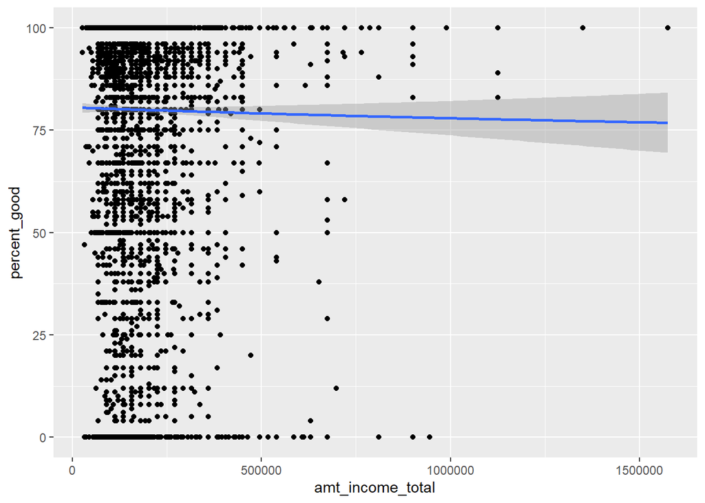

```r
ggplot(data = df.cc, mapping = aes(y = percent_good, x = amt_income_total)) +
  geom_point() + geom_smooth()
```

Here, we can see that there are few accounts (26) with a total income above 750K, it would be recommended to omit or recenter focus for regression as accuracy of the prediction would be reduced in this higher income range.

### 4.1.2 Categorical Variables

Next we plot the categorical variables against our dependent variable. The boxplots indicate that the median for name_education_type, name_housing_type, name_family_status, occupation_type, and flag_realty are the same (100%), however their factor levels differ in spread. This suggests there may exist a relationship between these variables and the dependent variable.

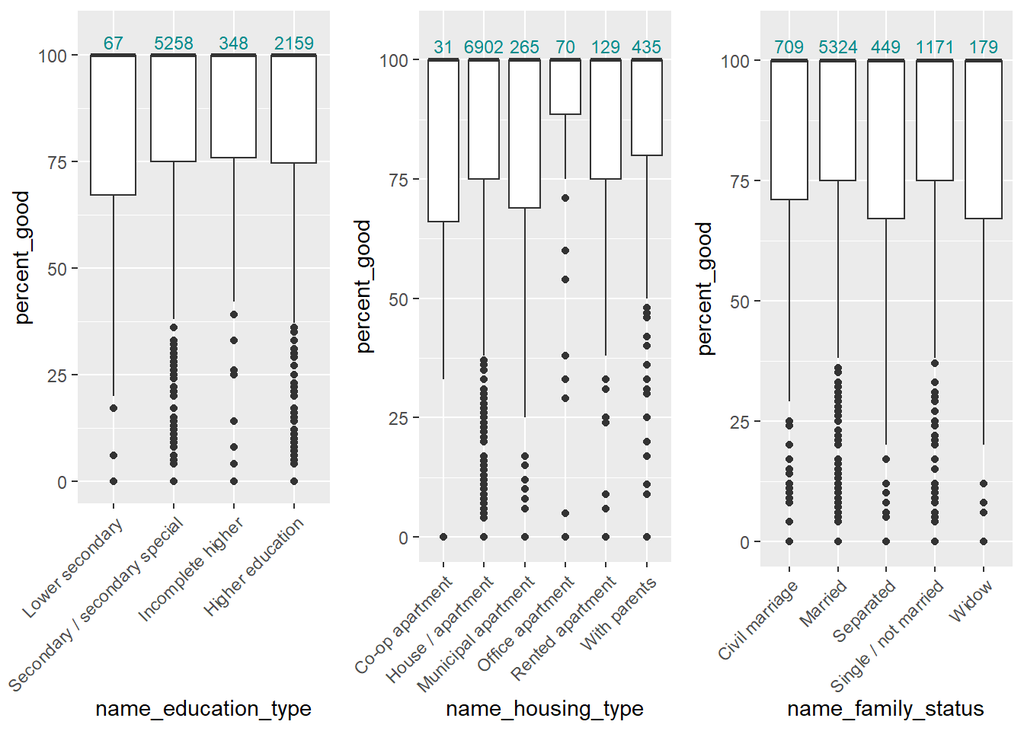

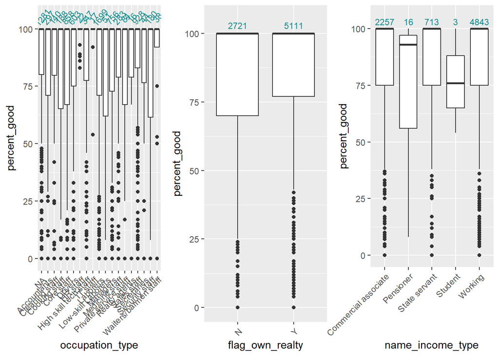

```r
plot.ed <- ggplot(data = df.cc, mapping = aes(y = percent_good, x = name_education_type)) +
  geom_boxplot() + theme(axis.text.x=element_text(angle=45, hjust=1)) +
  geom_text(aes(label = ..count..), y = 103, stat = "count", size = 3, color="darkcyan") + coord_cartesian(ylim=c(0,105))
# Note: only code for one plot is shown here due to limited space
```

Inspecting the predictor name_income_type, pensioners and students seem to have lower percentage of paying off loans within 60 days than other income types and so we consider this variable when fitting the model. We do need to be cautious here, as these two factor levels have very small base sizes.

The remaining categorical variables seem to show no influence on percent_good, based on inspection of the boxplots.

### 4.1.3 Count Variables

Plotting the variables cnt_fam_members and cnt_children, we see some difference in spread. Intuitively, we know there is a relationship between the two variables.

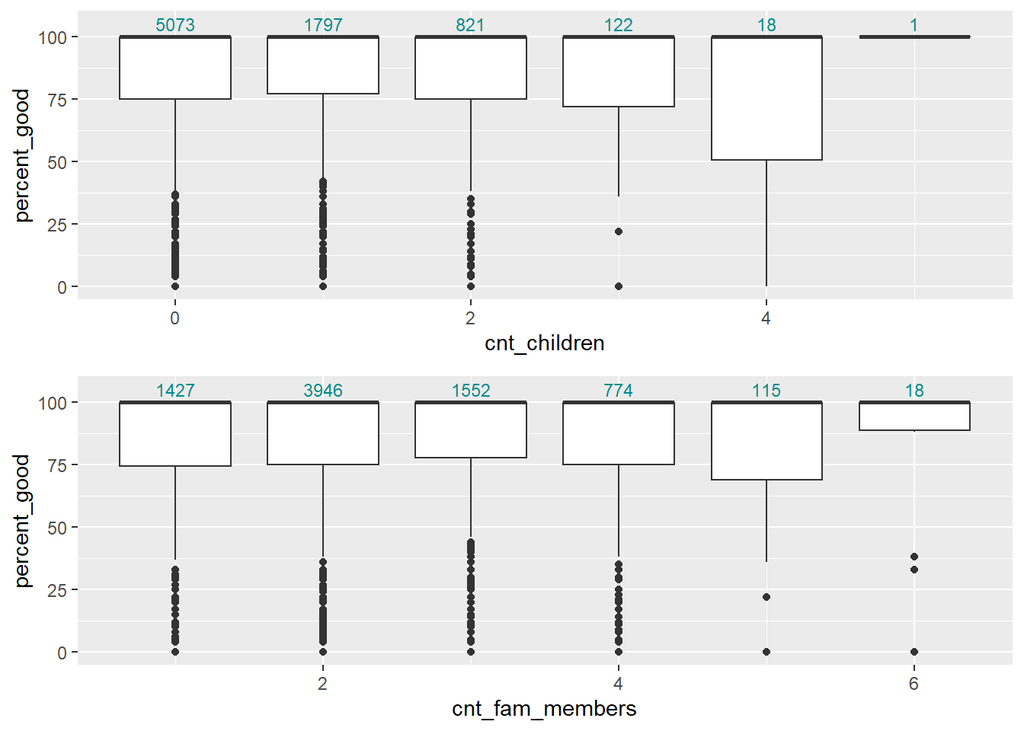

```r
plot.children <- ggplot(data = df.cc, mapping = aes(y = percent_good, x = cnt_children, group = as.factor(cnt_children))) + geom_boxplot() +
  geom_text(aes(label = ..count..), y = 105, stat = "count", size = 3, color="darkcyan") + coord_cartesian(ylim=c(0,105))

plot.family <- ggplot(data = df.cc, mapping = aes(y = percent_good, x = cnt_fam_members, group = as.factor(cnt_fam_members))) + geom_boxplot() +
  geom_text(aes(label = ..count..), y = 105, stat = "count", size = 3, color="darkcyan") + coord_cartesian(ylim=c(0,105))

grid.arrange(plot.children, plot.family, nrow=2)
```

### 4.1.4 Collinearity

With a few of the variables, there is the possibility of collinearity, specifically between age_years and work_years, and cnt_fam_members and cnt_children. We inspect this by plotting the variables against one another.

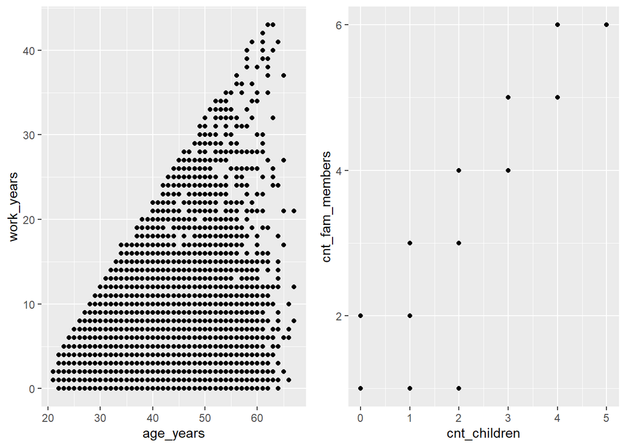

```r
plot.c.years <- ggplot(data = df.cc, mapping = aes(y = work_years, x = age_years)) + geom_point()

plot.c.family <- ggplot(data = df.cc, mapping = aes(y = cnt_fam_members, x = cnt_children)) + geom_point()

grid.arrange(plot.c.years, plot.c.family, ncol=2)
```

```r
vif(lm(percent_good ~ age_years + work_years, data = df.cc))
vif(lm(percent_good ~ cnt_children + cnt_fam_members, data = df.cc))
```

[output not shown]

Looking at the count variables, we can see the pairs are correlated. With a GVIF value of 5.011578, it is recommended that one of the variables cnt_children or cnt_fam_members should be dropped.

### 4.1.5 Interactions

Next we investigate whether there are interactions between the variables previously identified. Despite no clear relationship between age_year and percent_good, there could still be an interaction with other variables, so we start with age_year plotted against the other possible independent variables and make the following observations:  
- different housing types seem to have different slopes, suggesting an interaction with age  
- customers with 5 or 6 family members seem to be concentrated in the 30-45 age range, while the other family sizes are more distributed  
- few data points for some occupation types; no realty agents younger than 30

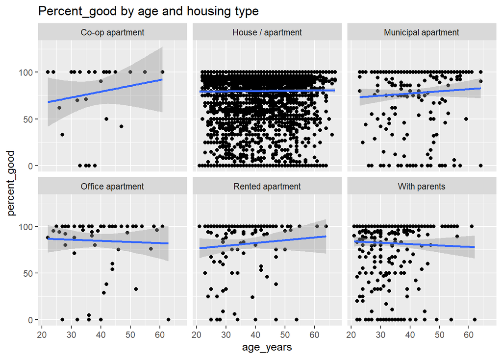

```r
ggplot(data = df.cc, mapping = aes(y = percent_good, x = age_years, group = name_housing_type)) +
  geom_point() + geom_smooth(method="lm") + facet_wrap(~name_housing_type) +
  ggtitle("Percent_good by age and housing type")
```

With amt_income_total, we identify some potential interactions with name_education_type, name_housing_type, and occupation_type.

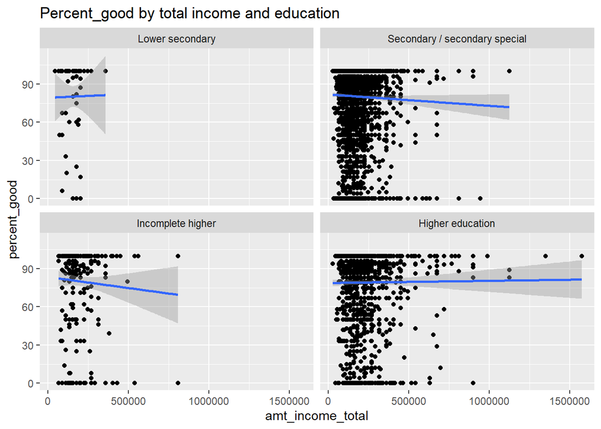

```r
ggplot(data = df.cc, mapping = aes(y = percent_good, x = amt_income_total, group = name_education_type)) +
  geom_point() + geom_smooth(method="lm") + facet_wrap(~name_education_type) +
  ggtitle("Percent_good by total income and education")
```

```r
# Note: only code and single plot are shown here due to limited space
```

We also see some interaction between cnt_fam_members and flag_own_realty.

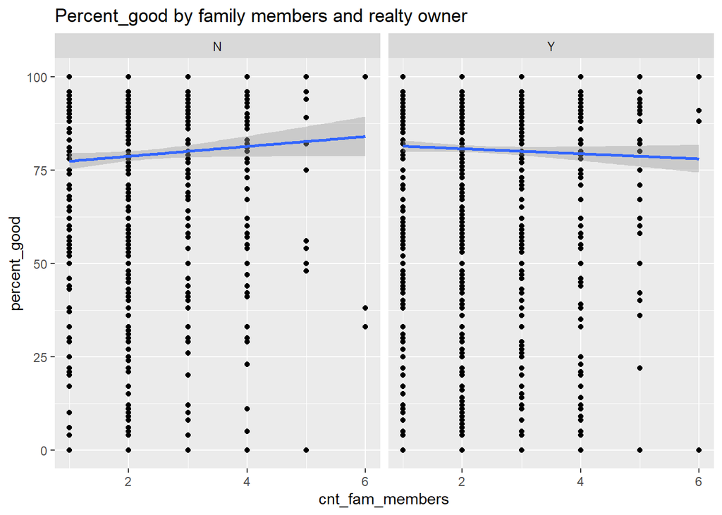

```r
ggplot(data = df.cc, mapping = aes(y = percent_good, x = cnt_fam_members, group = flag_own_realty)) +
  geom_point() + geom_smooth(method="lm") + facet_wrap(~flag_own_realty) +
  ggtitle("Percent_good by family members and realty owner")
```

Possible interactions identified from plots:  
- age_year:name_housing_type, age_year:flag_own_realty, age_year:cnt_fam_members  
- amt_income_total:name_housing_type, amt_income_total:occupation_type, amt_income_total:name_family_status, amt_income_total:name_education_type  
- cnt_fam_members:name_family_status, cnt_fam_members:education(lower secondary), cnt_fam_members:flag_own_realty  
- name_education_type:occupation_type

## 4.2 Fit Models

### 4.2.1 Global F-test

Beginning with a quick global F-test, we check if any of the predictors have an influence on the response variable, by comparing the full model, lm.fit.1 (all variables and interactions), against a model with only the intercept (lm.fit.0). This gives evidence that at least one of predictors plays a relevant role, albeit weakly. Using drop1() suggests keeping the interactions flag_own_realty:cnt_fam_members and name_education_type:occupation_type.

Refitting and checking the new model (lm.fit.2) against the model with only the intercept (lm.fit.0) gives a stronger indicator that at least one of the variables has an influence.

```r
anova(lm.fit.0, lm.fit.2)
```

```
## Analysis of Variance Table
##
## Model 1: percent_good ~ 1
## Model 2: percent_good ~ name_education_type + occupation_type + flag_own_realty +
##     cnt_fam_members + cnt_fam_members:flag_own_realty + name_education_type:occupation_type
##   Res.Df     RSS Df Sum of Sq      F   Pr(>F)
## 1   7831 8751689
## 2   7761 8633227 70    118462 1.5213 0.003403 **
## ---
## Signif. codes:  0 '***' 0.001 '**' 0.01 '*' 0.05 '.' 0.1 ' ' 1
```

```r
drop1(lm.fit.2, test = "F")
```

```
## Single term deletions
##
## Model:
## percent_good ~ name_education_type + occupation_type + flag_own_realty +
##     cnt_fam_members + cnt_fam_members:flag_own_realty + name_education_type:occupation_type
##                                     Df Sum of Sq     RSS   AIC F value  Pr(>F)
## <none>                                           8633227 55006
## flag_own_realty:cnt_fam_members      1      5880 8639108 55010  5.2864 0.02152
## name_education_type:occupation_type 46     66408 8699635 54974  1.2978 0.08540
##
## <none>
## flag_own_realty:cnt_fam_members     *
## name_education_type:occupation_type .
## ---
## Signif. codes:  0 '***' 0.001 '**' 0.01 '*' 0.05 '.' 0.1 ' ' 1
```

### 4.2.2 Simple Regression Models

An alternate method of model development, we start by fitting simple regression models with each of the identified independent variables and use summary() to test continuous variables and drop1() to test categorical variables.

```r
lm.fit.occupation <- lm(percent_good ~ occupation_type, data = df.cc)
drop1(lm.fit.occupation, test = "F")   # statistically significant
```

```
## Single term deletions
##
## Model:
## percent_good ~ occupation_type
##                 Df Sum of Sq     RSS   AIC F value   Pr(>F)
## <none>                       8712639 54974
## occupation_type 18     39050 8751689 54973  1.9455 0.009519 **
## ---
## Signif. codes:  0 '***' 0.001 '**' 0.01 '*' 0.05 '.' 0.1 ' ' 1
```

The output shows that occupation_type is statistically significant and using anova() to compare against a model that contains only an intercept, there is strong evidence the model with more parameters better fits the data (lower RSS for model with occupation_type, significant p-value), as seen in the output below.

```r
anova(lm.fit.0, lm.fit.occupation)
```

```
## Analysis of Variance Table
##
## Model 1: percent_good ~ 1
## Model 2: percent_good ~ occupation_type
##   Res.Df     RSS Df Sum of Sq      F   Pr(>F)
## 1   7831 8751689
## 2   7813 8712639 18     39050 1.9455 0.009519 **
## ---
## Signif. codes:  0 '***' 0.001 '**' 0.01 '*' 0.05 '.' 0.1 ' ' 1
```

Adding the other variables, we see that only flag_own_realty is statistically significant.

```r
lm.fit.occ.realty <- update(lm.fit.occupation, . ~ . + flag_own_realty)
drop1(lm.fit.occ.realty, test = "F")
```

```
## Single term deletions
##
## Model:
## percent_good ~ occupation_type + flag_own_realty
##                 Df Sum of Sq     RSS   AIC F value   Pr(>F)
## <none>                       8708109 54972
## occupation_type 18     39372 8747482 54971  1.9623 0.008721 **
## flag_own_realty  1      4529 8712639 54974  4.0633 0.043859 *
## ---
## Signif. codes:  0 '***' 0.001 '**' 0.01 '*' 0.05 '.' 0.1 ' ' 1
```

```r
anova(lm.fit.occupation, lm.fit.occ.realty)
```

```
## Analysis of Variance Table
##
## Model 1: percent_good ~ occupation_type
## Model 2: percent_good ~ occupation_type + flag_own_realty
##   Res.Df     RSS Df Sum of Sq      F  Pr(>F)
## 1   7813 8712639
## 2   7812 8708109  1    4529.4 4.0633 0.04386 *
## ---
## Signif. codes:  0 '***' 0.001 '**' 0.01 '*' 0.05 '.' 0.1 ' ' 1
```

Comparing with the previous model (lm.fit.occupation), we see evidence that the more complex model is a better fit to the data.

### 4.2.3 Regression Models with Interaction

We had identified 2 variables that showed potential interaction with occupation_type, and 2 with flag_own_realty, we look at these now to determine whether interactions should be included in the model.

```r
lm.fit.interact.4 <- update(lm.fit.occ.realty, . ~ . + cnt_fam_members + flag_own_realty:cnt_fam_members)
drop1(lm.fit.interact.4, test = "F")
```

```
## Single term deletions
##
## Model:
## percent_good ~ occupation_type + flag_own_realty + cnt_fam_members +
##     flag_own_realty:cnt_fam_members
##                                 Df Sum of Sq     RSS   AIC F value   Pr(>F)
## <none>                                       8702107 54971
## occupation_type                 18     39167 8741274 54970  1.9529 0.009159 **
## flag_own_realty:cnt_fam_members  1      5977 8708083 54974  5.3638 0.020584 *
## ---
## Signif. codes:  0 '***' 0.001 '**' 0.01 '*' 0.05 '.' 0.1 ' ' 1
```

```r
anova(lm.fit.occ.realty, lm.fit.interact.4)
```

```
## Analysis of Variance Table
##
## Model 1: percent_good ~ occupation_type + flag_own_realty
## Model 2: percent_good ~ occupation_type + flag_own_realty + cnt_fam_members +
##     flag_own_realty:cnt_fam_members
##   Res.Df     RSS Df Sum of Sq      F  Pr(>F)
## 1   7812 8708109
## 2   7810 8702107  2    6002.3 2.6935 0.06771 .
## ---
## Signif. codes:  0 '***' 0.001 '**' 0.01 '*' 0.05 '.' 0.1 ' ' 1
```

Here there is only weak evidence that the flag_own_realty:cnt_fam_members interaction plays a role.

## 4.3 Measures of Fit

### 4.3.1 In-sample performance

To quantify the goodness of fit, we look at the R^2 and adjusted R^2 values:

|  | R.squared | Adjusted.R.squared |
| --- | --- | --- |
| occupation_type | 0.00446 | 0.00217 |
| occupation_type + flag_own_realty | 0.00498 | 0.00256 |
| occupation_type + flag_own_realty + flag_own_realty:cnt_fam_members | 0.00567 | 0.00299 |

We see that the model with interaction has the best R^2 value, and, taking into account the differing complexity of the models, it still shows a slightly higher adjusted R^2, but not by much.

### 4.3.2 Out-of-sample performance

Now, we use part of the data to train the model and then test predictive performance on the remaining portion.

```r
set.seed(1)
indices <- createDataPartition(df.cc$percent_good, p=.85, list=F)
train <- df.cc %>% slice(indices)
test_in <- df.cc %>% slice(-indices) %>% select(-customer_status_good, -percent_good)
test_true <- df.cc %>% slice(-indices) %>% select(percent_good)
```

```r
# lm.fit.occupation
lm.train.1 <- lm(formula=formula(lm.fit.occupation), data = train)
predict.1.test <- predict(object = lm.train.1, newdata = test_in)

# lm.fit.occ.realty
lm.train.2 <- lm(formula=formula(lm.fit.occ.realty), data = train)
predict.2.test <- predict(object = lm.train.2, newdata = test_in)

# lm.fit.interact.4
lm.train.3 <- lm(formula=formula(lm.fit.interact.4), data = train)
predict.3.test <- predict(object = lm.train.3, newdata = test_in)
```

This yields the following R^2 values:

|  | R-squared |
| --- | --- |
| occupation_type | 0.00105 |
| occupation_type + flag_own_realty | 0.00198 |
| occupation_type + flag_own_realty + flag_own_realty:cnt_fam_members | 0.00309 |

# 5 GLM (Poisson)

# 6 GLM (Binomial)

# 7 GAM

# 8 SVM

# 9 Neural Networks

## 9.1 Build the network

```r
set.seed(1400)

# Work with copy of df.cc
df.ann <- cbind(df.cc)

# Standardize
df.ann$log_amt_income_total <- log(df.ann$amt_income_total)

## Only get needed columns for model
keeps <- c(
          "customer_status_good"
          ,"code_gender"
          ,"age_years"
          ,"name_education_type"
          ,"name_income_type"
          ,"name_housing_type"
          ,"name_family_status"
           ,"cnt_fam_members"
          ,"flag_own_car"
          ,"flag_own_realty"
          , "log_amt_income_total"
          ,"occupation_type"
           )

df.ann <- df.ann[keeps]


# Split data into train and test data sets
intrain <- createDataPartition(y = df.ann$customer_status_good,
                               p=0.65,
                               list = FALSE)
df.ann.training <- df.ann[intrain,]
df.ann.testing <- df.ann[-intrain,]

# Fit model
df.ann.net <- nnet(customer_status_good ~ ., data = df.ann.training, size=15, maxit=500, range=0.1, decay=5e-4, MaxNWts = 10000, trace = FALSE)
```

The model is designed as 41-15-1 network with 646 weights. 11 predictors were added to the model, but it works in total with 41 predictors as some of the variables are factors, which will be converted to dummy variables (0/1 values).

## 9.2 Make Predictions

```r
pred <- predict(df.ann.net, df.ann.testing, type="class")
cm_nn <- table(pred=pred, true=df.ann.testing$customer_status_good)
cm_nn
```

```
##     true
## pred    0    1
##    0   19   88
##    1  421 2212
```

Calculating the accuracy

```r
sum(diag(cm_nn))/sum(sum(cm_nn))
```

```
## [1] 0.8142336
```

Percentage of identified ‘bad’ customers

```r
cm_nn[1, 1]/(cm_nn[1, 1] + cm_nn[2, 1])
```

```
## [1] 0.04318182
```

```r
cm_nn[1, 1] + cm_nn[2, 1]
```

```
## [1] 440
```

The accuracy indicates a good score (0.8142336). However, simply predict all customers as good customers would lead to a even higher accurary (approx. 0.84). The model has issues to identify bad customers. It identifies 107 bad customers, but most of them are in fact good customers. Out of the 440 ‘real’ bad customers the model identifies only 19.

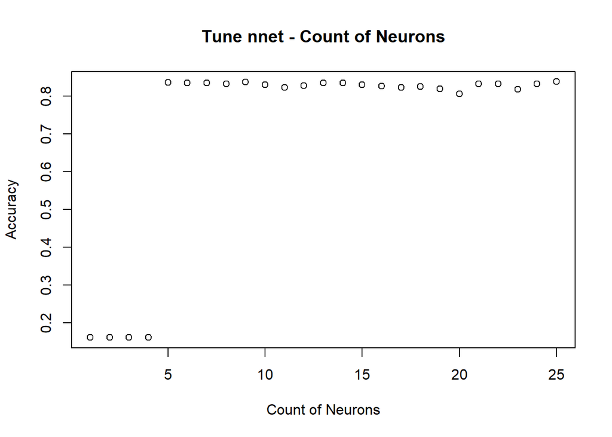

```r
# Tune nnet with function for different size of neurons
x <- c()
for (i in 1:25) {
  df.ann.net <- nnet(customer_status_good ~ ., data = df.ann.training, size=i, maxit=100, range=0.1, decay=5e-4, MaxNWts = 10000, trace = FALSE)
  pred <- predict(df.ann.net, df.ann.testing, type="class")
  cm_nn <- table(pred=pred, true=df.ann.testing$customer_status_good)
  s <- sum(diag(cm_nn))/sum(sum(cm_nn))
  x <- append(x, s)
}
plot(x, main="Tune nnet - Count of Neurons", ylab= "Accuracy", xlab = "Count of Neurons")
```

This function helps to tune the amount of neurons for the model. However, there is no model, which helps to find a high accuracy and is able to identify bad customers well.

Importance of the predictors

```r
df.ann.net.imp <- varImp(df.ann.net)
df.ann.net.imp <- df.ann.net.imp[order(-df.ann.net.imp$Overall),, drop = FALSE]
head(df.ann.net.imp, 10)
```

```
##                                        Overall
## age_years                            11.641278
## log_amt_income_total                  4.439373
## cnt_fam_members                       3.468985
## flag_own_carY                         3.093140
## code_genderM                          2.996132
## occupation_typeLaborers               2.892416
## name_housing_typeMunicipal apartment  2.683630
## occupation_typeHigh skill tech staff  2.657693
## occupation_typeSales staff            2.619351
## flag_own_realtyY                      2.544774
```

This table shows the importance of the different predictors (list of top 10 out of 41).

# 10 Optimization

The distinction between good and bad customer is a way to build up a relatively safe portfolio of customers, who repay their debts with the interest. However, the defined threshold leaves room for optimization.

Potential options to increase earnings through optimization include:

**1. Granting credit cards to a percentage of “bad” applicants**  
This adds a marginally higher risk to the portfolio of credit card customers, however, comes with higher possible returns.

**2. Allocating credit limits**  
Determining the credit limit to allow an applicant/customer based on their likelihood to repay (i.e. “percent_good”) in order to maximize interest paid, thereby increasing earnings.

**3. Dunning**  
It is lucrative for credit card companies when customers do not immediately repay the loan amounts they borrow. Depending on the agreed contract, the companies can claim additional fees and penalty interest from a certain point. The dunning system should take this into account and not dun the customer too early or the full amount as overdue. However, it should be noted that the later the reminder is issued, the greater the likelihood of a credit default (untested assumption). It is therefore appropriate to demand regular partial payments.

To optimize (maximize) the profit of a credit card company the following **simplified** formular could be applied:

**Maximize $g(x,y) =$ “loan amount” $\cdot$ “interest rate” $\cdot \frac{x}{360} +$ “additional fees” $–$ “loan amount” $\cdot$ “probability of default”$(x,y)$**

Control variables:  
$x =$ days until dunning letter will be sent  
$y =$ amount of partial payment

Probability of default is another function based on $x$ and $y$. The higher the value of $x$ and the lower the value of $y$, it can be assumed that the probability of default will be increased.

Constraints are defined based on the agreed contracts between the company and the customers. For example, there it can be defined the minimum days until an amount is overdue (e.g. $x >=$ 30 days).